# Project IGF10

2025-03-03

Vous devrez répondre aux questions avec des lignes de codes

# Introduction

1. design experimental

1.a. Contexte biologique Nous avons comparé deux populations cellulaires issues d’embryons de 2 types de souris : des cellules issues de souris WT (sauvages) et des cellules issues de souris mutantes Knock Out par le système cre-lox (expression de Cre ayant délété le gène cible flanqué de sites Loxp). Pour caractériser l’impact transcriptionnel de cette délétion, nous avons quantifié par RT‑qPCR l’expression de 24 gènes représentatifs des trois feuillets embryonnaires (endoderme, mésoderme, ectoderme) ainsi que des marqueurs de la pluripotence.

1.b.Conditions expérimentales Chaque condition (WT et KO) comprenait trois (03) réplicats biologiques et trois(03) réplicats techniques. Les valeurs médianes et moyennes de Ct de la RT-qPCR ont été d’abord normalisées sur un gène de ménage, transformées en dCT, puis ensuite en ddCt pour calculer leurs variations d’expression relatives qui est le Fold change. Une analyse en composantes principales (PCA) a été réalisée sur les profils d’expression relatifs afin de visualiser la séparation globale entre WT et KO pour identifier le gène dont l’expression est la plus affectée par la recombinaison Cre‑Lox. Enfin, Une RNA‑seq nous permettra d’identifier quels gènes changent d’expression entre les differentes conditions, et l’analyse Gene Ontology (GO) traduit ces listes de gènes en fonctions biologiques, composants cellulaires et activités moléculaires pour étayer nos hypothèses biologiques.

install.packages(“magick”)

```r
library(magick)
```

[figure not shown]

```r
img <- image_read("cre_lox.png")
print(img, info = FALSE)
```

2. question scientifique La question scientifique ici posée est : Comment la délétion Cre‑Lox d’un gène cible influence‑t‑elle l’expression des gènes de différenciation embryonnaire (endoderme, mésoderme, ectoderme, pluripotence) dans des cellules embryonnaires de souris ?

# Analyses des données de RT-qPCR

## Charger les packages

```r
library(tidyverse)
library(ggpubr)
library(readxl)
```

```r
library(dplyr)
library(tidyr)
library(stringr)
library(ggplot2)
if (!require("BiocManager", quietly = TRUE))
    install.packages("BiocManager")
library(BiocManager)
BiocManager::install("DESeq2")
BiocManager::install("ComplexHeatmap")
BiocManager::install("goseq")
BiocManager::install("clusterProfiler")
BiocManager::install("org.Mm.eg.db")
```

## Charger les données

```r
qpcr_dat<-read_excel("Data10.xlsx")
```

Le tableau doit ressembler à cela (attention les valeurs seront différentes):

[figure not shown]

*Question 1.1: combien de gènes ont été analysés?*

```r
qpcr_dat|>
  distinct(Gene)|>
  nrow()
```

```
## [1] 24
```

*Question 1.2: Combien d’échantillons ont été analysés?*

```r
ncol(qpcr_dat)-1
```

```
## [1] 6
```

*Question 1.3: Combien de réplicats techniques sont effectué pas échantillons pour chaque gène*

```r
table(qpcr_dat$Gene)
```

```
##
##   Foxa2   Gata4   Gata6   Hand2   Hnf4a    Klf4   Krt14   Mesp1   Mixl1   Msgn1
##       3       3       3       3       3       3       3       3       3       3
##   Nanog  Nestin Neurog1    Otx2    Pax6  Pdgfra    Pdx1  Pou5F1   Sox17    Sox2
##       3       3       3       3       3       3       3       3       3       3
##     TBP    TBra    Tbx6   Zfp42
##       3       3       3       3
```

## Transformer le tableau pour avoir une seul colonne d’expression de gène

```r
qpcr_dat_long<-pivot_longer(qpcr_dat,cols=2:7,names_to="Sample",values_to="Ct")

head(qpcr_dat_long)
```

```
## # A tibble: 6 × 3
##   Gene  Sample     Ct
##   <chr> <chr>   <dbl>
## 1 Foxa2 WT_Rep1  20.9
## 2 Foxa2 WT_Rep2  21.3
## 3 Foxa2 WT_Rep3  21.8
## 4 Foxa2 KO_Rep1  21
## 5 Foxa2 KO_Rep2  21.4
## 6 Foxa2 KO_Rep3  21.9
```

Le tableau doit ressembler à cela:

[figure not shown]

*Question 2: quelles sont les nouvelles dimensions de ce tableau?*

```r
dim(qpcr_dat_long)
```

```
## [1] 432   3
```

## Ajouter des métadatas sur le tableau principale

Une métadata est une information sur l’échantillon qui sera importante plus tard pour filtrer les données

### Ouvrir le tableau de fonction des gènes

```r
meta<-read.table("fonction_gène.txt","\t",h=T)
```

*Question 3: quelles sont les différentes catégories de gènes?*

```r
unique(meta$Fonction)
```

```
## [1] "Endoderme"    "Mesoderme"    "Ectoderme"    "Pluripotence" "GDM"
```

### Ajouter les metadata sur le tableau principal

```r
qpcr_combined<-merge(qpcr_dat_long,meta,by="Gene")
```

Le tableau doit ressembler à cela:

[figure not shown]

### Créer deux colonnes à partir de la colonne Sample

L’obejctif est de séparer la chaîne de caractère contenue dans “Sample” en deux colonnes que l’on pourra appeler “CellType” et “BioRep”. Ajouter ces deux colonnes dans le tableau principal.

Indice: utilisez la fonction **str_split_fixed()**

```r
str_split<-str_split_fixed(qpcr_combined$Sample,"_", n=2)
colnames(str_split)<-c("CellType","BioRep")
head(str_split)
```

```
##      CellType BioRep
## [1,] "WT"     "Rep1"
## [2,] "WT"     "Rep2"
## [3,] "WT"     "Rep3"
## [4,] "KO"     "Rep1"
## [5,] "KO"     "Rep2"
## [6,] "KO"     "Rep3"
```

```r
qpcr_combined_split<-cbind.data.frame(qpcr_combined,str_split)
```

Le tableau doit ressembler à cela:

[figure not shown]

## Calcul du 2^-ddct

### calculer les médianes des réplicats techniques

Pensez à éliminer la colonne Ct et ensuite les valeurs redondante après le calcul des médianes et si vous groupez pensez à dégrouper à la fin de votre code.

```r
qpcr_median<-qpcr_combined_split|>
  group_by(Gene,Sample)|>
  mutate("Med_Ct"=median(Ct))|>
  distinct(Gene,.keep_all = T)|>
  ungroup()
head(qpcr_median)
```

```
## # A tibble: 6 × 7
##   Gene  Sample     Ct Fonction  CellType BioRep Med_Ct
##   <chr> <chr>   <dbl> <chr>     <chr>    <chr>   <dbl>
## 1 Foxa2 WT_Rep1  20.9 Endoderme WT       Rep1     20.8
## 2 Foxa2 WT_Rep2  21.3 Endoderme WT       Rep2     21.3
## 3 Foxa2 WT_Rep3  21.8 Endoderme WT       Rep3     22.4
## 4 Foxa2 KO_Rep1  21   Endoderme KO       Rep1     20.9
## 5 Foxa2 KO_Rep2  21.4 Endoderme KO       Rep2     21.4
## 6 Foxa2 KO_Rep3  21.9 Endoderme KO       Rep3     22.5
```

*Question 4: quelles sont les dimensions de cette nouvelle table?*

```r
dim(qpcr_median)
```

```
## [1] 144   7
```

### caluler les dCt

#### extraire les valeur de Ct du gène de ménage

```r
data_GDM<-qpcr_median|>
  filter(Fonction=="GDM")
```

#### verifier l’expression du GDM

plotter les valeurs de Ct afin d’observer si les gènes de ménages sont comparable. Si possible ajouter une analyse statistique avec la fonction **stat_compare_means()**

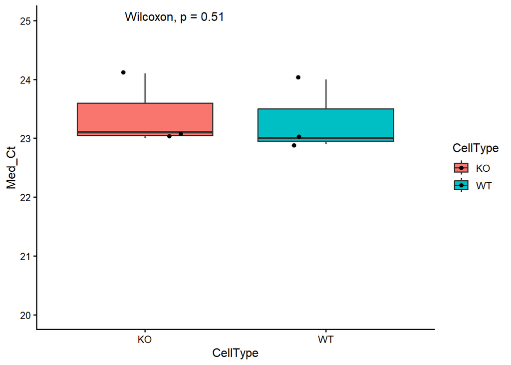

```r
ggplot(data_GDM,aes(x=CellType,y=Med_Ct,fill = CellType))+geom_boxplot()+geom_jitter(width=0.2)+
  ylim(c(20,25))+
  stat_compare_means()+theme_classic2()
```

voici un résultat possible:

[figure not shown]

*Question 5: que pouvez vous conclure des Ct entre WT et KO?*

#### Ajouter les medianes des Ct du GDM pour chaque échantillon

indice: pour le dataframe du GDM ne garder que les colonnes “Sample” et “MedCt”

```r
data_GDM_small<-data_GDM|>
  select(Sample,Med_Ct)
colnames(data_GDM_small)<-c("Sample","Med_Ct_GDM")
qpcr_GDM_long<-qpcr_median|>
  merge(y=data_GDM_small,by="Sample")
head(qpcr_GDM_long)
```

```
##    Sample  Gene   Ct     Fonction CellType BioRep Med_Ct Med_Ct_GDM
## 1 KO_Rep1 Mesp1 37.8    Mesoderme       KO   Rep1   37.8         23
## 2 KO_Rep1 Mixl1 31.6    Mesoderme       KO   Rep1   31.5         23
## 3 KO_Rep1 Msgn1 31.5    Mesoderme       KO   Rep1   31.5         23
## 4 KO_Rep1 Sox17 22.6    Endoderme       KO   Rep1   22.3         23
## 5 KO_Rep1 Nanog 31.6 Pluripotence       KO   Rep1   31.4         23
## 6 KO_Rep1 Foxa2 21.0    Endoderme       KO   Rep1   20.9         23
```

#### calculer les dCt

```r
qpcr_dCt<-qpcr_GDM_long|>
  mutate(dCt=Med_Ct-Med_Ct_GDM)
```

Le tableau doit ressembler à cela:

[figure not shown]

### PCA

#### Créer une table avec seulement Gene, Sample et dCt

```r
qpcr_dCt_split<-qpcr_dCt|>
  select(Gene,Sample,dCt)
```

#### transformer le tableau pour avoir les échantillon en colonne et les gènes en ligne

```r
qpcr_dCt_wide<-qpcr_dCt_split|>
  pivot_wider(names_from ="Sample",values_from ="dCt")
head(qpcr_dCt_wide)
```

```
## # A tibble: 6 × 7
##   Gene  KO_Rep1 KO_Rep2 KO_Rep3 WT_Rep1 WT_Rep2 WT_Rep3
##   <chr>   <dbl>   <dbl>   <dbl>   <dbl>   <dbl>   <dbl>
## 1 Mesp1  14.8    14.8     14.2   -5      -4.1    -4.2
## 2 Mixl1   8.5     9.2      9     -0.600   0.300   0.100
## 3 Msgn1   8.5     9.2      8.9   -0.5     0.400   0
## 4 Sox17  -0.700   0.100    0     -0.700   0.100   0
## 5 Nanog   8.4     9.2      9      8.6     9.2     9
## 6 Foxa2  -2.10   -1.7     -1.60  -2.10   -1.7    -1.60
```

Le tableau doit ressembler à cela:

[figure not shown]

#### faire la PCA

indice: utiliser la fonction **prcomp()** attention à ne prendre que les valeurs numérique

```r
PCA_data<-prcomp(qpcr_dCt_wide[,2:ncol(qpcr_dCt_wide)])
head(PCA_data)
```

```
## $sdev
## [1] 9.80239776 5.63727397 0.47629820 0.26989694 0.12913100 0.06273661
##
## $rotation
##                PC1        PC2         PC3        PC4        PC5         PC6
## KO_Rep1 -0.5177643 -0.2644203 -0.05089246  0.6445893  0.1458861 -0.47184090
## KO_Rep2 -0.5136584 -0.2537243  0.54560634 -0.2184382  0.3451052  0.45528006
## KO_Rep3 -0.5197833 -0.2518802 -0.48391582 -0.4177182 -0.5063450  0.03651606
## WT_Rep1 -0.2511947  0.5310317 -0.07140065  0.4910963 -0.3025914  0.56309092
## WT_Rep2 -0.2554352  0.5127753  0.51596024 -0.2424900 -0.3215050 -0.49338881
## WT_Rep3 -0.2637319  0.5072761 -0.44072230 -0.2496477  0.6389893 -0.09082348
##
## $center
##   KO_Rep1   KO_Rep2   KO_Rep3   WT_Rep1   WT_Rep2   WT_Rep3
## 3.2716667 3.8800000 3.6175000 0.5800000 1.2925000 0.9841667
```

[output cut: 55 more lines]

```r
PCA_coord<-as.data.frame(PCA_data$rotation)
class(PCA_coord)
```

```
## [1] "data.frame"
```

```r
PCA_coord_small<-PCA_coord|>
  select(PC1,PC2)
PCA_coord_small$Sample<-rownames(PCA_coord_small)
PCA_data$sdev
```

```
## [1] 9.80239776 5.63727397 0.47629820 0.26989694 0.12913100 0.06273661
```

*Question 6.1: Observez l’objet créer. Où sont les nouvelles coordonnées des 6 échantillons dans le nouveau repère calculé par la PCA?*

*Question 6.2: Où sont les nouvelles variances représentées par chaque PC?*

#### plotter la PCA

plottez seulement PC1 et PC2

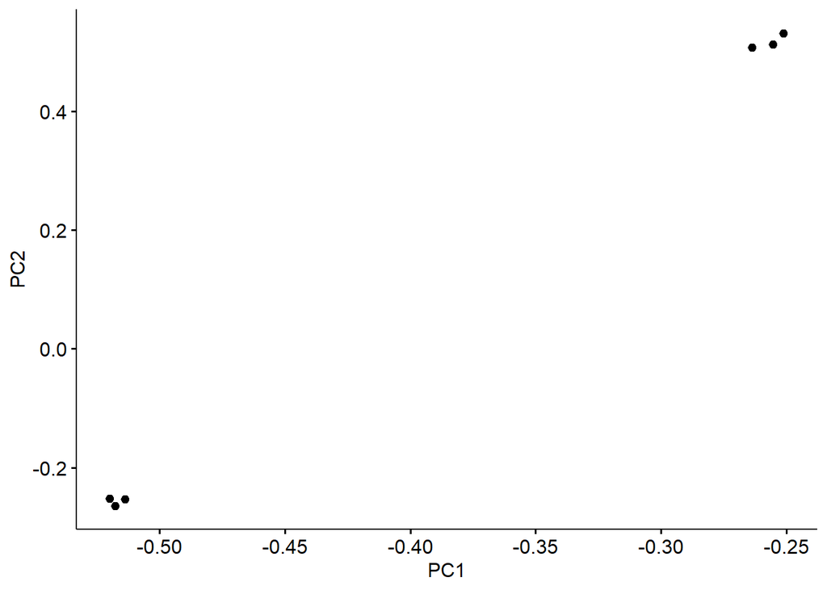

```r
ggscatter(PCA_coord,x="PC1",y="PC2")
```

Un graphique possible:

[figure not shown]

#### plotter le elbow plot

grâce au valeure de variance *sdev* il est possible de caluler un pourcentage de variance et de plotter chaque PC contre la variance. Ce plot aura pour géométrie une ligne

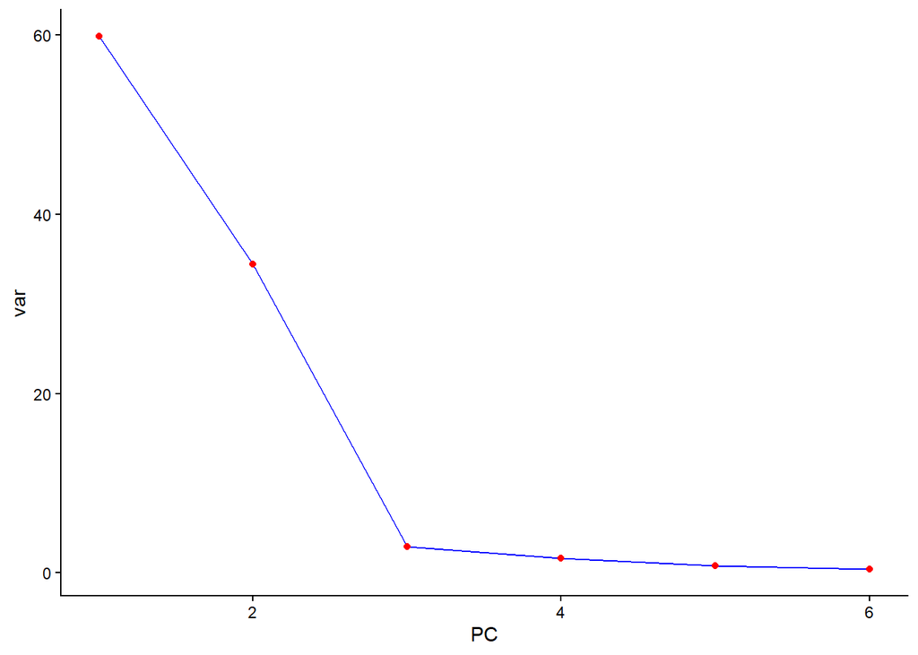

```r
qpcr_variance<-(PCA_data$sdev/sum(PCA_data$sdev))*100
elbow_data<-cbind.data.frame(1:6, qpcr_variance)
colnames(elbow_data)<-c("PC","var")
ggplot(elbow_data,aes(x=PC,y=var))+
  geom_line(color="blue")+
  geom_point(color="red")+
  theme_classic()
```

Un graphique possible:

[figure not shown]

### calculer les 2ddCt ou Fold change

#### extraire les échanillons WT qui vont nous servir de contrôle

```r
qpcr_dCt_Wt<-qpcr_dCt|>filter(CellType=="WT")
```

#### calculer la moyenne des réplicats biologique pour chaque gene

```r
qpcr_dCt_Wt_mean<-qpcr_dCt_Wt|>
  group_by(Gene)|>
  summarise("Mean_Ct"=mean(dCt))
head(qpcr_dCt_Wt_mean)
```

```
## # A tibble: 6 × 2
##   Gene  Mean_Ct
##   <chr>   <dbl>
## 1 Foxa2 -1.8
## 2 Gata4  0.743
## 3 Gata6 -4.43
## 4 Hand2  0.0667
## 5 Hnf4a  0.267
## 6 Klf4   8.87
```

#### Ajouter les moyennes à la table principale

```r
qpcr_dCt_Wt_mean_combined<-qpcr_dCt|>merge(qpcr_dCt_Wt_mean,by="Gene")
head(qpcr_dCt_Wt_mean_combined)
```

```
##    Gene  Sample   Ct  Fonction CellType BioRep Med_Ct Med_Ct_GDM  dCt Mean_Ct
## 1 Foxa2 KO_Rep2 21.4 Endoderme       KO   Rep2   21.4       23.1 -1.7    -1.8
## 2 Foxa2 WT_Rep1 20.9 Endoderme       WT   Rep1   20.8       22.9 -2.1    -1.8
## 3 Foxa2 KO_Rep3 21.9 Endoderme       KO   Rep3   22.5       24.1 -1.6    -1.8
## 4 Foxa2 WT_Rep2 21.3 Endoderme       WT   Rep2   21.3       23.0 -1.7    -1.8
## 5 Foxa2 KO_Rep1 21.0 Endoderme       KO   Rep1   20.9       23.0 -2.1    -1.8
## 6 Foxa2 WT_Rep3 21.8 Endoderme       WT   Rep3   22.4       24.0 -1.6    -1.8
```

#### Calculer les 2ddCt

```r
qpcr_data_delta<-qpcr_dCt_Wt_mean_combined|>
  mutate(ddCt= dCt-Mean_Ct,Foldchange=2^(-ddCt))
head(qpcr_data_delta)
```

```
##    Gene  Sample   Ct  Fonction CellType BioRep Med_Ct Med_Ct_GDM  dCt Mean_Ct
## 1 Foxa2 KO_Rep2 21.4 Endoderme       KO   Rep2   21.4       23.1 -1.7    -1.8
## 2 Foxa2 WT_Rep1 20.9 Endoderme       WT   Rep1   20.8       22.9 -2.1    -1.8
## 3 Foxa2 KO_Rep3 21.9 Endoderme       KO   Rep3   22.5       24.1 -1.6    -1.8
## 4 Foxa2 WT_Rep2 21.3 Endoderme       WT   Rep2   21.3       23.0 -1.7    -1.8
## 5 Foxa2 KO_Rep1 21.0 Endoderme       KO   Rep1   20.9       23.0 -2.1    -1.8
## 6 Foxa2 WT_Rep3 21.8 Endoderme       WT   Rep3   22.4       24.0 -1.6    -1.8
##   ddCt Foldchange
## 1  0.1  0.9330330
## 2 -0.3  1.2311444
## 3  0.2  0.8705506
## 4  0.1  0.9330330
## 5 -0.3  1.2311444
## 6  0.2  0.8705506
```

### boxplot

avec les statistiques: legende: ns: p > 0.05 : p <= 0.05 : p <= 0.01 : p <= 0.001 ****: p <= 0.0001

indice: utiliser facet_wrap pour avoir un boxplot par gène et la focntion des gènes pour les couleurs

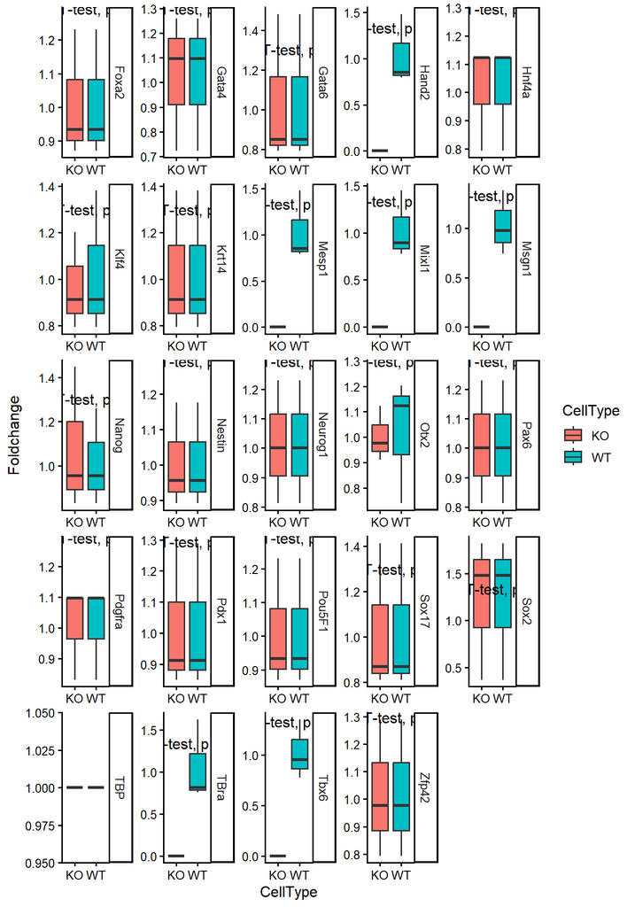

```r
ggplot(qpcr_data_delta,aes(x=CellType,y=Foldchange,fill=CellType))+
  geom_boxplot()+facet_wrap(~Gene,scales="free",strip.position="right")+
  stat_compare_means(method="t.test",label.y=max(qpcr_data_delta$Foldchange)*0.7)+
  theme_classic2()
```

*Question 7: Quel est le gène édité dans votre jeu de donnée?* indice: c’est le Fold change le plus important

```r
qpcr_data_delta|>
  filter(CellType=="KO")|>
  arrange(desc(abs(ddCt)))|>
  dplyr::select(Gene,Foldchange)|>
  head()
```

```
##    Gene   Foldchange
## 1 Mesp1 1.622519e-06
## 2 Mesp1 1.622519e-06
## 3 Mesp1 2.459279e-06
## 4 Mixl1 1.623512e-03
## 5 Hand2 1.661459e-03
## 6 Msgn1 1.661459e-03
```

*Question 8: Quel tissu est le plus affecté par la mutation?* Donner la réponse en ligne de code en filtrant les Fold change

```r
qpcr_data_delta|>filter(CellType=="KO")|>
  group_by(Fonction)|>
  summarise(Differentiel_moyenne=mean(abs(ddCt)))|>
  arrange(desc(Differentiel_moyenne))
```

```
## # A tibble: 5 × 2
##   Fonction     Differentiel_moyenne
##   <chr>                       <dbl>
## 1 Mesoderme                  10.5
## 2 Ectoderme                   0.322
## 3 Endoderme                   0.267
## 4 Pluripotence                0.244
## 5 GDM                         0
```

# Analyses des données de RNAseq

## Création du DESeq dataset

### Charger le tableau de count

```r
getwd()
```

```
## [1] "E:/L3 BCP/Projet IGF 10"
```

```r
list.files()
```

```
##  [1] "1_readcsv.png"
##  [2] "2_pivotlonger.png"
##  [3] "3_meta1.png"
##  [4] "4_meta2.png"
##  [5] "5_GDM.png"
##  [6] "6_dCt.png"
##  [7] "7_pivotwider.png"
##  [8] "8_PCA.png"
##  [9] "9_elbow.png"
## [10] "cre_lox.png"
## [11] "Data10.xlsx"
## [12] "fonction_gène.txt"
## [13] "GSE30352_All_SRAs.txt"
## [14] "Liver_vs_Kidney.csv"
## [15] "Projet_IGF_SANON_Armand_Leonce.Rmd"
## [16] "Projet_IGF_SANON_Armand_Leonce_files"
## [17] "RNAseq_countTable_new.csv"
```

```r
RNA_dat<-read.csv("RNAseq_countTable_new.csv",h=T,se=",",row.names = 1)
head(RNA_dat)
```

```
##       EchA_rep1 EchA_rep2 EchB_rep1 EchB_rep EchC_rep1 EchC_rep2
## Gnai3         2        33         1      201       154       166
## Pbsn          0         0         0        0         0         0
## Cdc45         0         0         0        0         0         2
## H19           0         1         0        1         0         0
## Scml2         0         1         0        1         0         0
## Apoh          0         0         0       13      1497      2442
```

```r
dim(RNA_dat)
```

```
## [1] 55109     6
```

```r
RNA_dat_mat<-as.matrix(RNA_dat)
```

### Charger les métadata

```r
samplecondition<-read.csv("GSE30352_All_SRAs.txt",sep="\t")
head(samplecondition)
```

```
##         Run   Age Assay.Type AvgSpotLen      Bases  BioProject    BioSample
## 1 SRR306764 adult    RNA-Seq         76 1592028164 PRJNA143627 SAMN00632159
## 2 SRR306765 adult    RNA-Seq         76 2181979000 PRJNA143627 SAMN00632160
## 3 SRR306770 adult    RNA-Seq         76 1796622064 PRJNA143627 SAMN00632165
## 4 SRR306771 adult    RNA-Seq         76 2216025784 PRJNA143627 SAMN00632166
## 5 SRR306773 adult    RNA-Seq         76 1401775616 PRJNA143627 SAMN00632168
## 6 SRR306774 adult    RNA-Seq         76 2584775808 PRJNA143627 SAMN00632169
##        Bytes Center.Name Consent DATASTORE.filetype DATASTORE.provider
## 1 1263997305         GEO  public sra\trun.zq\tfastq       s3\tncbi\tgs
## 2 1707714028         GEO  public sra\trun.zq\tfastq       ncbi\tgs\ts3
## 3 1408576123         GEO  public run.zq\tsra\tfastq       ncbi\ts3\tgs
## 4 1739098395         GEO  public sra\tfastq\trun.zq       ncbi\ts3\tgs
## 5 1117001510         GEO  public run.zq\tsra\tfastq       s3\tncbi\tgs
## 6 2027944500         GEO  public fastq\tsra\trun.zq       gs\tncbi\ts3
##                   DATASTORE.region Experiment Extraction gender
```

[output cut: 41 more lines]

### Créer l’objet DESeq

```r
library(DESeq2)
```

```r
dds<-DESeqDataSetFromMatrix(RNA_dat_mat,samplecondition,~source_name)
dds
```

```
## class: DESeqDataSet
## dim: 55109 6
## metadata(1): version
## assays(1): counts
## rownames(55109): Gnai3 Pbsn ... CT485612.1 AC158307.1
## rowData names(0):
## colnames(6): EchA_rep1 EchA_rep2 ... EchC_rep1 EchC_rep2
## colData names(33): Run Age ... SRA.Study tissue_source
```

## Nettoyage des gènes avec peu de counts

```r
threshold<-3
keep<-rowSums(counts(dds))>=threshold
dds<-dds[keep,]
dds
```

```
## class: DESeqDataSet
## dim: 15452 6
## metadata(1): version
## assays(1): counts
## rownames(15452): Gnai3 Apoh ... AL590864.1 CT010467.2
## rowData names(0):
## colnames(6): EchA_rep1 EchA_rep2 ... EchC_rep1 EchC_rep2
## colData names(33): Run Age ... SRA.Study tissue_source
```

## Gène différentiellement exprimés

```r
dds$source_name<-factor(dds$source_name)
dds<-DESeq(dds)
res<-results(object=dds,contrast = c("source_name","Kidney","Liver"))
res
```

```
## log2 fold change (MLE): source_name Kidney vs Liver
## Wald test p-value: source_name Kidney vs Liver
## DataFrame with 15452 rows and 6 columns
##                baseMean log2FoldChange     lfcSE      stat      pvalue
##               <numeric>      <numeric> <numeric> <numeric>   <numeric>
## Gnai3          32.37348      -1.139924   0.97419 -1.170125 2.41951e-01
## Apoh          246.42542      -8.406994   1.03554 -8.118426 4.72269e-16
## Narf           12.63353      -1.729649   1.39889 -1.236447 2.16292e-01
## Cav2            3.06915       0.907239   2.20006  0.412370 6.80068e-01
## Klf6            6.46543       1.125109   1.89706  0.593081 5.53127e-01
## ...                 ...            ...       ...       ...         ...
## AC135859.1     0.749919      -0.930737   4.40640 -0.211224    0.832713
## A930007A09Rik  0.139191       4.388451   4.88935  0.897553    0.369424
## Gm4988         0.246460       0.000000   4.89233  0.000000    1.000000
## AL590864.1     2.202155      -2.982112   3.28291 -0.908375    0.363680
## CT010467.2     0.113332       4.246218   4.89004  0.868340    0.385208
##                      padj
##                 <numeric>
## Gnai3         9.07357e-01
## Apoh          9.21099e-14
## Narf          8.56387e-01
## Cav2                   NA
## Klf6          1.00000e+00
## ...                   ...
## AC135859.1             NA
## A930007A09Rik          NA
## Gm4988                 NA
## AL590864.1             NA
## CT010467.2             NA
```

## Extraire les infos pour les DEGs

### Résumé des résultats

```r
summary(res)
```

```
##
## out of 15452 with nonzero total read count
## adjusted p-value < 0.1
## LFC > 0 (up)       : 91, 0.59%
## LFC < 0 (down)     : 289, 1.9%
## outliers [1]       : 0, 0%
## low counts [2]     : 10186, 66%
## (mean count < 5)
## [1] see 'cooksCutoff' argument of ?results
## [2] see 'independentFiltering' argument of ?results
```

### Sortir les DEGs significatifs

```r
sum(res$padj<0.05,na.rm=T)
```

```
## [1] 299
```

### Sauver les datas

```r
resOrdred<-res[order(res$"log2FoldChange",decreasing=T),]
resOrdred
```

```
## log2 fold change (MLE): source_name Kidney vs Liver
## Wald test p-value: source_name Kidney vs Liver
## DataFrame with 15452 rows and 6 columns
##          baseMean log2FoldChange     lfcSE      stat      pvalue        padj
##         <numeric>      <numeric> <numeric> <numeric>   <numeric>   <numeric>
## Kap      206.4433        13.1095   4.78641   2.73891 6.16437e-03 8.89358e-02
## Slc12a1   74.7830        11.6563   3.31169   3.51975 4.31948e-04 9.99415e-03
## Fut9      67.7374        10.7171   1.67939   6.38156 1.75289e-10 1.33778e-08
## Slc5a12   35.8817        10.5956   4.79382   2.21027 2.70865e-02 2.71691e-01
## Acsm2     98.1097        10.5652   2.64530   3.99394 6.49831e-05 1.94432e-03
## ...           ...            ...       ...       ...         ...         ...
## Trf      1351.741       -11.8911   1.17300 -10.13737 3.77100e-24 7.49883e-21
## Fabp1     421.186       -12.2757   1.27605  -9.62008 6.57804e-22 4.94857e-19
## Mup3      456.486       -12.3964   1.27237  -9.74280 1.98017e-22 2.08551e-19
## Cps1      684.397       -12.9659   1.28409 -10.09732 5.67707e-24 7.49883e-21
## Alb     10009.643       -16.8538   1.27008 -13.26987 3.46182e-40 1.82300e-36
```

```r
write.csv(resOrdred,"Liver_vs_Kidney.csv")
```

## Visualistaion des datas

### PCA

```r
vsd<-vst(dds,blind=T)
```

```
## -- note: fitType='parametric', but the dispersion trend was not well captured by the
##    function: y = a/x + b, and a local regression fit was automatically substituted.
##    specify fitType='local' or 'mean' to avoid this message next time.
```

```
## using ntop=500 top features by variance
```

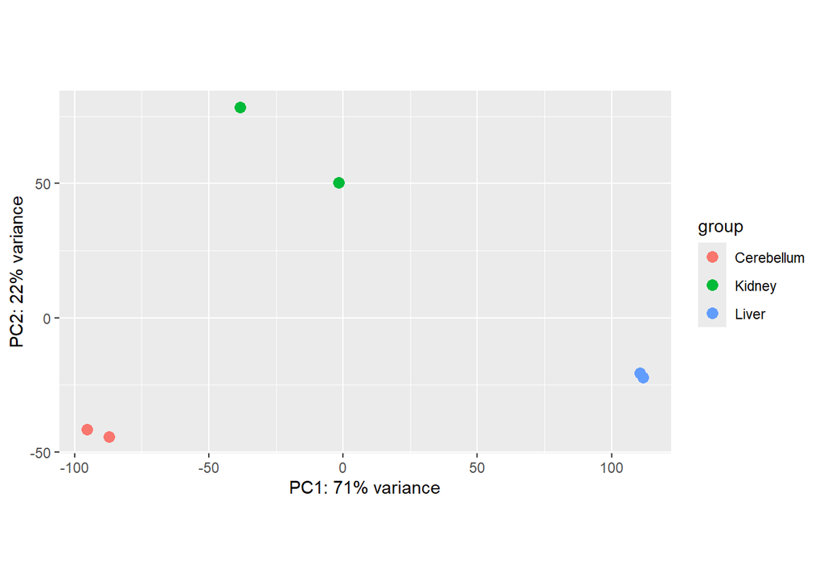

```r
plotPCA(vsd,intgroup="source_name",pcsToUse=1:2)
```

### MA plot

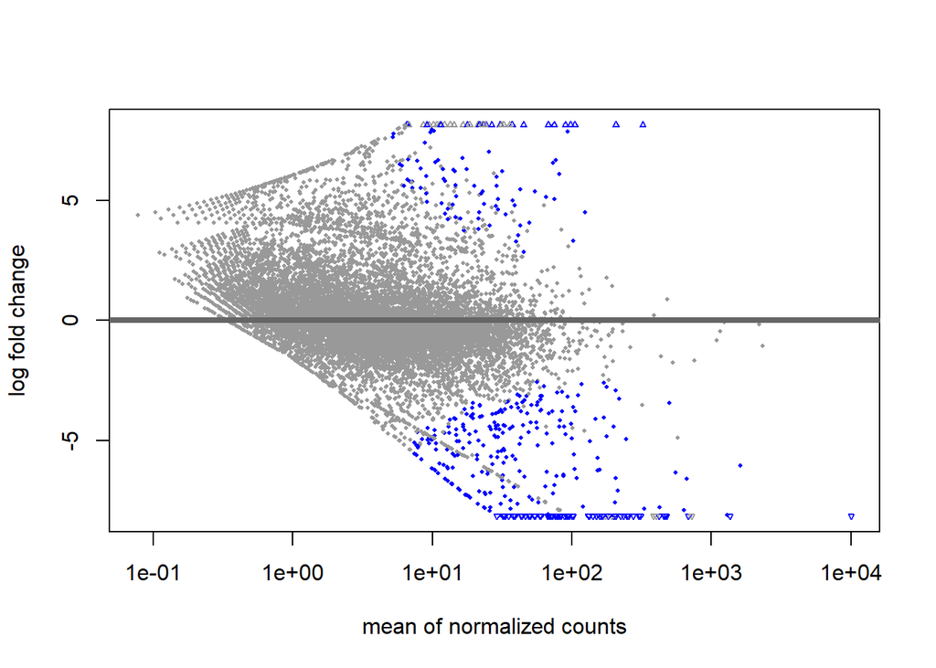

```r
DESeq2::plotMA(res)
```

### MA plot avec ggpubr

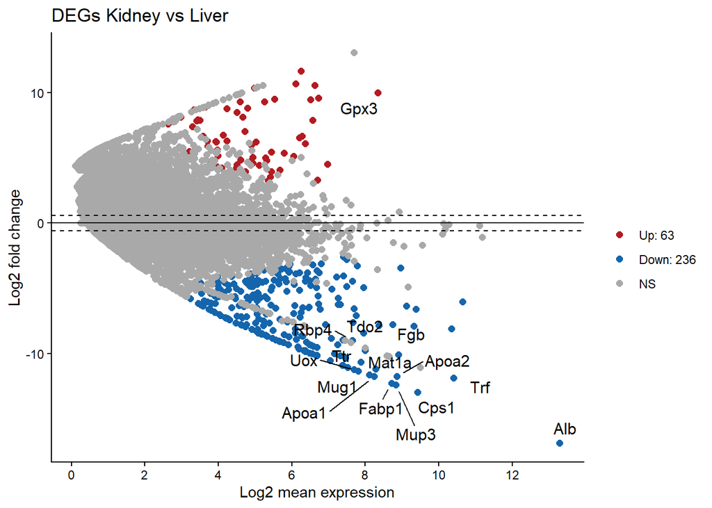

```r
ggmaplot(res,size=2,main="DEGs Kidney vs Liver")
```

### Heatmap avec les DEGs

```r
resDDS<-cbind.data.frame(res$log2FoldChange,res$padj)
rownames(resDDS)<-rownames(res)
colnames(resDDS)<-c("log2FC","padj")
head(resDDS)
```

```
##            log2FC         padj
## Gnai3 -1.13992424 9.073571e-01
## Apoh  -8.40699438 9.210994e-14
## Narf  -1.72964867 8.563874e-01
## Cav2   0.90723860           NA
## Klf6   1.12510878 1.000000e+00
## Scmh1 -0.08891191           NA
```

```r
resSIG<-resDDS|>filter(padj<0.05)
head(resSIG)
```

```
##              log2FC         padj
## Apoh      -8.406994 9.210994e-14
## Serpinf1  -7.784274 1.547422e-05
## Lgals9    -6.284618 1.056148e-04
## Tat      -10.901111 1.082339e-14
## Pon1      -9.952424 1.012690e-11
## Gnmt      -6.440392 2.565807e-07
```

```r
dim(resSIG)
```

```
## [1] 299   2
```

## Afficher le heatmap

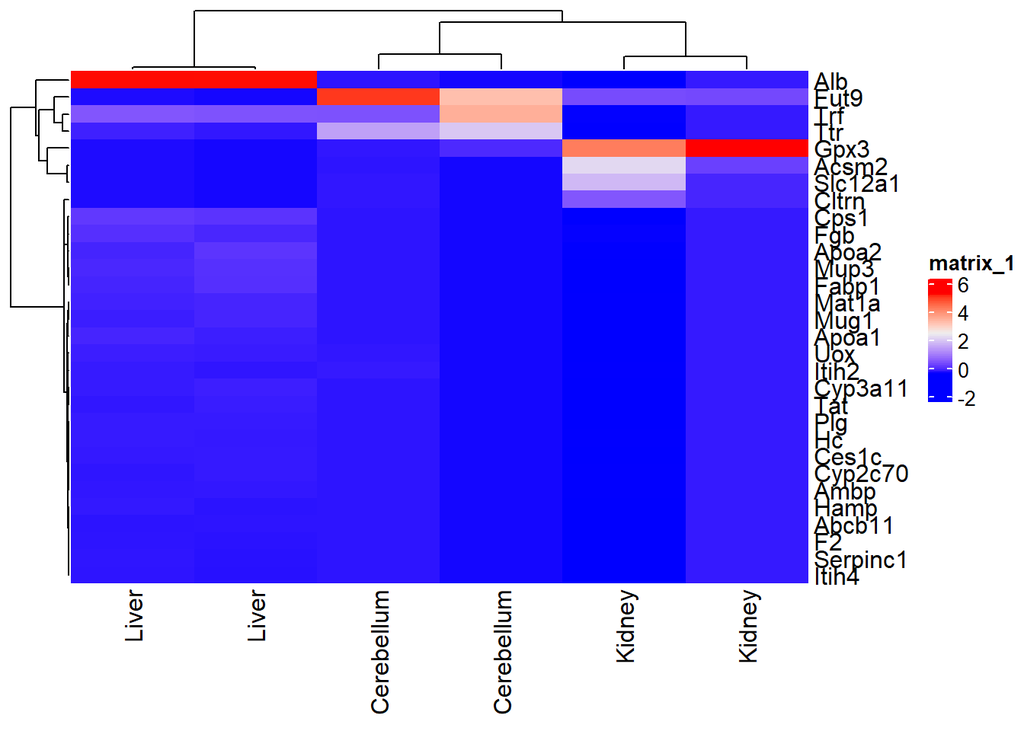

```r
library(ComplexHeatmap)
resSIGOrdered<-resSIG[order(abs(resSIG$log2FC),decreasing=T),]
resSIGOrdered_top30<-resSIGOrdered[1:30,]

RNA_dat<-as.data.frame(RNA_dat)

RNA_dat_SIG<-RNA_dat|>
  filter(row.names(RNA_dat)%in%row.names(resSIGOrdered_top30))

colnames(RNA_dat_SIG)<-dds$source_name

hm<-Heatmap(matrix=scale(RNA_dat_SIG),
            cluster_rows=TRUE,
            clustering_method_rows = "ward.D",
            cluster_columns = TRUE,
            clustering_method_columns = "ward.D",
            show_row_names = TRUE,
            show_column_names = TRUE)
hm
```

```r
hm<-Heatmap(matrix=scale(RNA_dat[1:100,]),
            cluster_rows=TRUE,
            clustering_method_rows = "ward.D2",
            cluster_columns = TRUE,
            clustering_method_columns = "ward.D2",
            show_row_names = FALSE,
            show_column_names = TRUE)
```

```
## The automatically generated colors map from the 1^st and 99^th of the
## values in the matrix. There are outliers in the matrix whose patterns
## might be hidden by this color mapping. You can manually set the color
## to `col` argument.
##
## Use `suppressMessages()` to turn off this message.
```

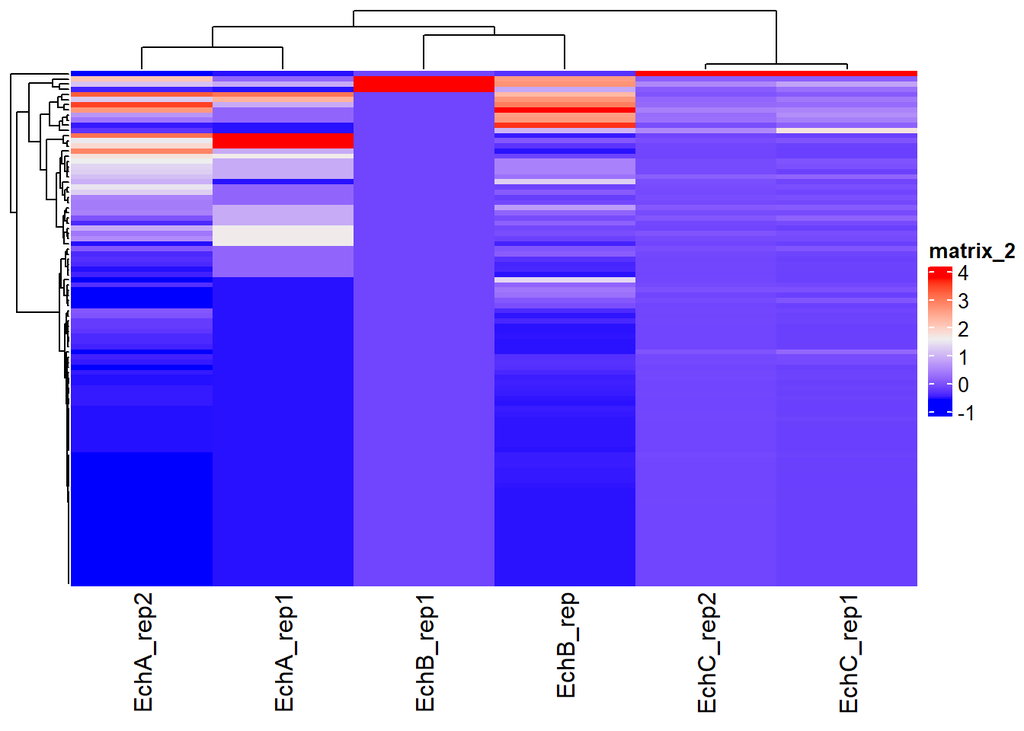

```r
hm
```

## Analyser les Gene Ontologies

```r
library(goseq)
library(org.Mm.eg.db)
library(clusterProfiler)
```

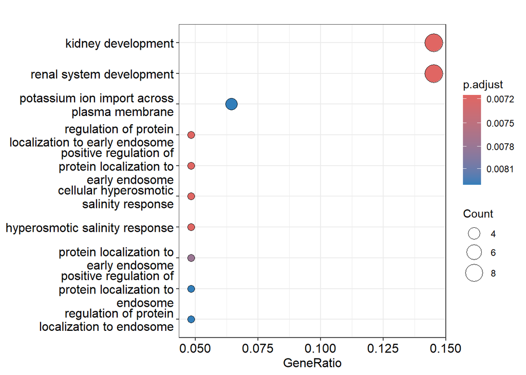

```r
#Plot les GO
bg_genes<-rownames(res)

#Choix des DEGs
resSIG<-resDDS|>
  filter(res$padj<0.05 & res$log2FoldChange>0)
resSIG_symbol<-rownames(resSIG)

#Calcul des gènes enrechis dans les ontologies
enrich_go<-enrichGO(
  gene=resSIG_symbol,
  OrgDb = org.Mm.eg.db,
  keyType = "SYMBOL",
  ont = "BP",
  universe = bg_genes,
  qvalueCutoff = 0.05,
  readable = TRUE
)

#Plot
dotplot(enrich_go)
```

```r
keytypes(org.Mm.eg.db)
```

```
##  [1] "ACCNUM"       "ALIAS"        "ENSEMBL"      "ENSEMBLPROT"  "ENSEMBLTRANS"
##  [6] "ENTREZID"     "ENZYME"       "EVIDENCE"     "EVIDENCEALL"  "GENENAME"
## [11] "GENETYPE"     "GO"           "GOALL"        "IPI"          "MGI"
## [16] "ONTOLOGY"     "ONTOLOGYALL"  "PATH"         "PFAM"         "PMID"
## [21] "PROSITE"      "REFSEQ"       "SYMBOL"       "UNIPROT"
```

# Conclusion